# Introduction to broom

Oleksiy Anokhin

January 12, 2019

This code was adapted from [“Introduction to broom”](https://cran.r-project.org/web/packages/broom/vignettes/broom.html) vignette

**Tidying functions** This package provides three S3 methods that do three distinct kinds of tidying.

- **tidy:** constructs a data frame that summarizes the model’s statistical findings. This includes coefficients and p-values for each term in a regression, per-cluster information in clustering applications, or per-test information for multtest functions.
- **augment:** add columns to the original data that was modeled. This includes predictions, residuals, and cluster assignments.
- **glance:** construct a concise one-row summary of the model. This typically contains values such as R^2, adjusted R^2, and residual standard error that are computed once for the entire model.

```r
# Packages
library(broom)
library(ggplot2)
```

Let’s create the first model.

```r
lmfit <- lm(mpg ~ wt, mtcars)
```

Another option to create and visualize model - ggplot2.

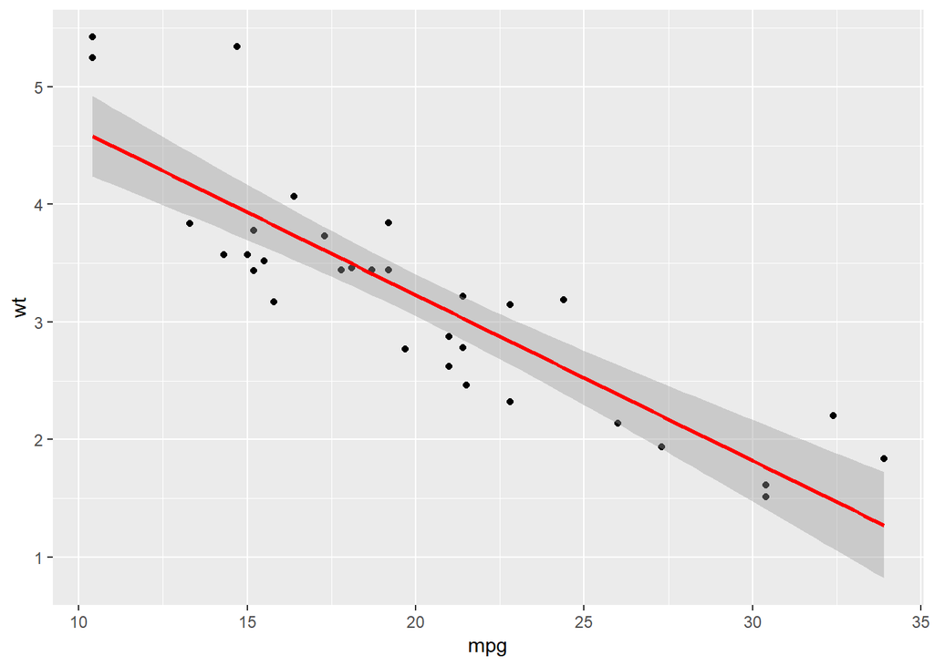

```r
ggplot(mtcars, aes(x = mpg, y = wt)) +
  geom_point() +
  stat_smooth(method = "lm", col = "red")
```

Let’s print model output.

Compare two options - traditional and tidy (with broom).

```r
summary(lmfit)
```

```
##
## Call:
## lm(formula = mpg ~ wt, data = mtcars)
##
## Residuals:
##     Min      1Q  Median      3Q     Max
## -4.5432 -2.3647 -0.1252  1.4096  6.8727
##
## Coefficients:
##             Estimate Std. Error t value Pr(>|t|)
## (Intercept)  37.2851     1.8776  19.858  < 2e-16 ***
## wt           -5.3445     0.5591  -9.559 1.29e-10 ***
## ---
## Signif. codes:  0 '***' 0.001 '**' 0.01 '*' 0.05 '.' 0.1 ' ' 1
##
## Residual standard error: 3.046 on 30 degrees of freedom
## Multiple R-squared:  0.7528, Adjusted R-squared:  0.7446
## F-statistic: 91.38 on 1 and 30 DF,  p-value: 1.294e-10
```

```r
tidy(lmfit)
```

```
## # A tibble: 2 x 5
##   term        estimate std.error statistic  p.value
##   <chr>          <dbl>     <dbl>     <dbl>    <dbl>
## 1 (Intercept)    37.3      1.88      19.9  8.24e-19
## 2 wt             -5.34     0.559     -9.56 1.29e-10
```

Which one do you like more? I like the second one.

This gives you a data.frame representation. Note that the row names have been moved into a column called **term**, and the column names are simple and consistent (and can be accessed using $).

Instead of viewing the coefficients, you might be interested in the fitted values and residuals for each of the original points in the regression. For this, use augment, which augments the original data with information from the model:

```r
augment(lmfit)
```

```
## # A tibble: 32 x 10
##    .rownames   mpg    wt .fitted .se.fit .resid   .hat .sigma .cooksd
##    <chr>     <dbl> <dbl>   <dbl>   <dbl>  <dbl>  <dbl>  <dbl>   <dbl>
##  1 Mazda RX4  21    2.62    23.3   0.634 -2.28  0.0433   3.07 1.33e-2
##  2 Mazda RX~  21    2.88    21.9   0.571 -0.920 0.0352   3.09 1.72e-3
##  3 Datsun 7~  22.8  2.32    24.9   0.736 -2.09  0.0584   3.07 1.54e-2
##  4 Hornet 4~  21.4  3.22    20.1   0.538  1.30  0.0313   3.09 3.02e-3
##  5 Hornet S~  18.7  3.44    18.9   0.553 -0.200 0.0329   3.10 7.60e-5
##  6 Valiant    18.1  3.46    18.8   0.555 -0.693 0.0332   3.10 9.21e-4
##  7 Duster 3~  14.3  3.57    18.2   0.573 -3.91  0.0354   3.01 3.13e-2
##  8 Merc 240D  24.4  3.19    20.2   0.539  4.16  0.0313   3.00 3.11e-2
##  9 Merc 230   22.8  3.15    20.5   0.540  2.35  0.0314   3.07 9.96e-3
## 10 Merc 280   19.2  3.44    18.9   0.553  0.300 0.0329   3.10 1.71e-4
## # ... with 22 more rows, and 1 more variable: .std.resid <dbl>
```

Note that each of the new columns begins with a . (to avoid overwriting any of the original columns).

Finally, several summary statistics are computed for the entire regression, such as R^2 and the F-statistic. These can be accessed with the glance function:

```r
glance(lmfit)
```

```
## # A tibble: 1 x 11
##   r.squared adj.r.squared sigma statistic  p.value    df logLik   AIC   BIC
##       <dbl>         <dbl> <dbl>     <dbl>    <dbl> <int>  <dbl> <dbl> <dbl>
## 1     0.753         0.745  3.05      91.4 1.29e-10     2  -80.0  166.  170.
## # ... with 2 more variables: deviance <dbl>, df.residual <int>
```

These functions also work on other fits, such as nonlinear models (nls)

```r
nlsfit <- nls(mpg ~ k / wt + b, mtcars, start = list(k  =1, b = 0))
tidy(nlsfit)
```

```
## # A tibble: 2 x 5
##   term  estimate std.error statistic  p.value
##   <chr>    <dbl>     <dbl>     <dbl>    <dbl>
## 1 k        45.8       4.25     10.8  7.64e-12
## 2 b         4.39      1.54      2.85 7.74e- 3
```

```r
augment(nlsfit, mtcars)
```

```
## # A tibble: 32 x 14
##    .rownames   mpg   cyl  disp    hp  drat    wt  qsec    vs    am  gear
##    <chr>     <dbl> <dbl> <dbl> <dbl> <dbl> <dbl> <dbl> <dbl> <dbl> <dbl>
##  1 Mazda RX4  21       6  160    110  3.9   2.62  16.5     0     1     4
##  2 Mazda RX~  21       6  160    110  3.9   2.88  17.0     0     1     4
##  3 Datsun 7~  22.8     4  108     93  3.85  2.32  18.6     1     1     4
##  4 Hornet 4~  21.4     6  258    110  3.08  3.22  19.4     1     0     3
##  5 Hornet S~  18.7     8  360    175  3.15  3.44  17.0     0     0     3
##  6 Valiant    18.1     6  225    105  2.76  3.46  20.2     1     0     3
##  7 Duster 3~  14.3     8  360    245  3.21  3.57  15.8     0     0     3
##  8 Merc 240D  24.4     4  147.    62  3.69  3.19  20       1     0     4
##  9 Merc 230   22.8     4  141.    95  3.92  3.15  22.9     1     0     4
## 10 Merc 280   19.2     6  168.   123  3.92  3.44  18.3     1     0     4
## # ... with 22 more rows, and 3 more variables: carb <dbl>, .fitted <dbl>,
## #   .resid <dbl>
```

```r
glance(nlsfit)
```

```
## # A tibble: 1 x 8
##   sigma isConv       finTol logLik   AIC   BIC deviance df.residual
##   <dbl> <lgl>         <dbl>  <dbl> <dbl> <dbl>    <dbl>       <int>
## 1  2.77 TRUE   0.0000000288  -77.0  160.  164.     231.          30
```

**Hypothesis testing** The tidy function can also be applied to htest objects, such as those output by popular built-in functions like t.test, cor.test, and wilcox.test.

```r
tt <- t.test(wt ~ am, mtcars)
tidy(tt)
```

```
## # A tibble: 1 x 10
##   estimate estimate1 estimate2 statistic p.value parameter conf.low
##      <dbl>     <dbl>     <dbl>     <dbl>   <dbl>     <dbl>    <dbl>
## 1     1.36      3.77      2.41      5.49 6.27e-6      29.2    0.853
## # ... with 3 more variables: conf.high <dbl>, method <chr>,
## #   alternative <chr>
```

Some cases might have fewer columns (for example, no confidence interval):

```r
wt <- wilcox.test(wt ~ am, mtcars)
tidy(wt)
```

```
## # A tibble: 1 x 4
##   statistic   p.value method                                    alternative
##       <dbl>     <dbl> <chr>                                     <chr>
## 1      230. 0.0000435 Wilcoxon rank sum test with continuity c~ two.sided
```

Since the tidy output is already only one row, glance returns the same output:

```r
glance(tt)
```

```
## # A tibble: 1 x 10
##   estimate estimate1 estimate2 statistic p.value parameter conf.low
##      <dbl>     <dbl>     <dbl>     <dbl>   <dbl>     <dbl>    <dbl>
## 1     1.36      3.77      2.41      5.49 6.27e-6      29.2    0.853
## # ... with 3 more variables: conf.high <dbl>, method <chr>,
## #   alternative <chr>
```

```r
glance(wt)
```

```
## # A tibble: 1 x 4
##   statistic   p.value method                                    alternative
##       <dbl>     <dbl> <chr>                                     <chr>
## 1      230. 0.0000435 Wilcoxon rank sum test with continuity c~ two.sided
```

Augment method is defined only for chi-squared tests, since there is no meaningful sense, for other tests, in which a hypothesis test produces output about each initial data point.

```r
chit <- chisq.test(xtabs(Freq ~ Sex + Class, data = as.data.frame(Titanic)))
tidy(chit)
```

```
## # A tibble: 1 x 4
##   statistic  p.value parameter method
##       <dbl>    <dbl>     <int> <chr>
## 1      350. 1.56e-75         3 Pearson's Chi-squared test
```

```r
augment(chit)
```

```
## # A tibble: 8 x 9
##   Sex   Class .observed  .prop .row.prop .col.prop .expected .residuals
##   <fct> <fct>     <dbl>  <dbl>     <dbl>     <dbl>     <dbl>      <dbl>
## 1 Male  1st         180 0.0818    0.104     0.554      256.       -4.73
## 2 Fema~ 1st         145 0.0659    0.309     0.446       69.4       9.07
## 3 Male  2nd         179 0.0813    0.103     0.628      224.       -3.02
## 4 Fema~ 2nd         106 0.0482    0.226     0.372       60.9       5.79
## 5 Male  3rd         510 0.232     0.295     0.722      555.       -1.92
## 6 Fema~ 3rd         196 0.0891    0.417     0.278      151.        3.68
## 7 Male  Crew        862 0.392     0.498     0.974      696.        6.29
## 8 Fema~ Crew         23 0.0104    0.0489    0.0260     189.      -12.1
## # ... with 1 more variable: .stdres <dbl>
```